# NYCFlights: Arrival Delay Logistic Model

Jennifer Lee

April 29, 2017

## Logistic and Inverse Logistic Transformation

- Write an R function for the logistic function. The function should accept a `numeric` vector with values `[-Inf,Inf]` and produce a numeric vector in the the range `[0,1]`.
- Plot the logistic function from `[0,1]`
- Write an R function for the inverse logistic function. The function should accept a `numeric` vector with values `[0,1]` and produce a numeric vector in the range `[-Inf,Inf]`
- Plot the Inverse Logistic function from `[-10,10]`

**Hint:** For plotting curves see `?graphics::curve` or `?ggplot2::stat_function`

```r
#Part 1: Write an R function for the logistic function.

#Vector with values [-Inf,Inf]
l <- seq(-10,10, length=26)

#Plot logistic function from [0,1]
logistic <- function(t) {
  exp(t)/(1 + exp(t)) }

#Logistic function produces a vector in range [0,1]
vector <- logistic(l)
range(vector)
```

```
## [1] 4.539787e-05 9.999546e-01
```

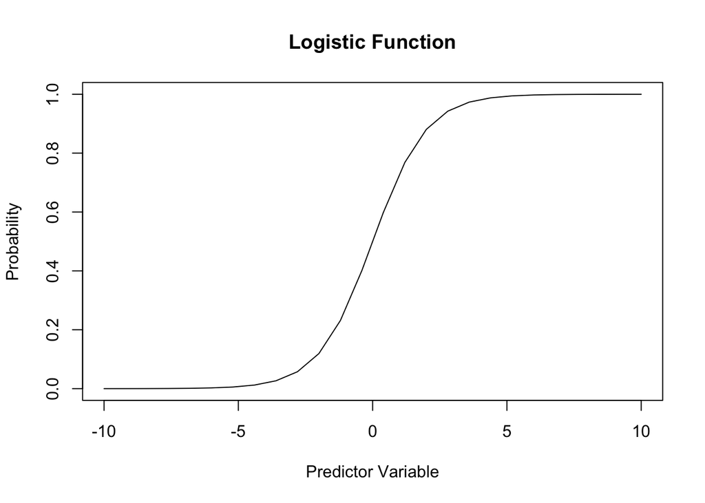

```r
#Plot logistic function
plot(logistic(l) ~ l, type = "l", main="Logistic Function", xlab="Predictor Variable",ylab="Probability")
```

```r
#Part 2: Write a R function for the inverse logistic function

#Vector with values [0,1]
x <- seq(0,1, length=100)
x <- x[2:(length(x)-1)]

#Inverse Logistic function
logit <- function (t) {
  log( t / (1-t) ) }

#Inverse Logistic function produces a vector in range [-Inf,Inf]
invvector <- (logit(x))
range(invvector)
```

```
## [1] -4.584967  4.584967
```

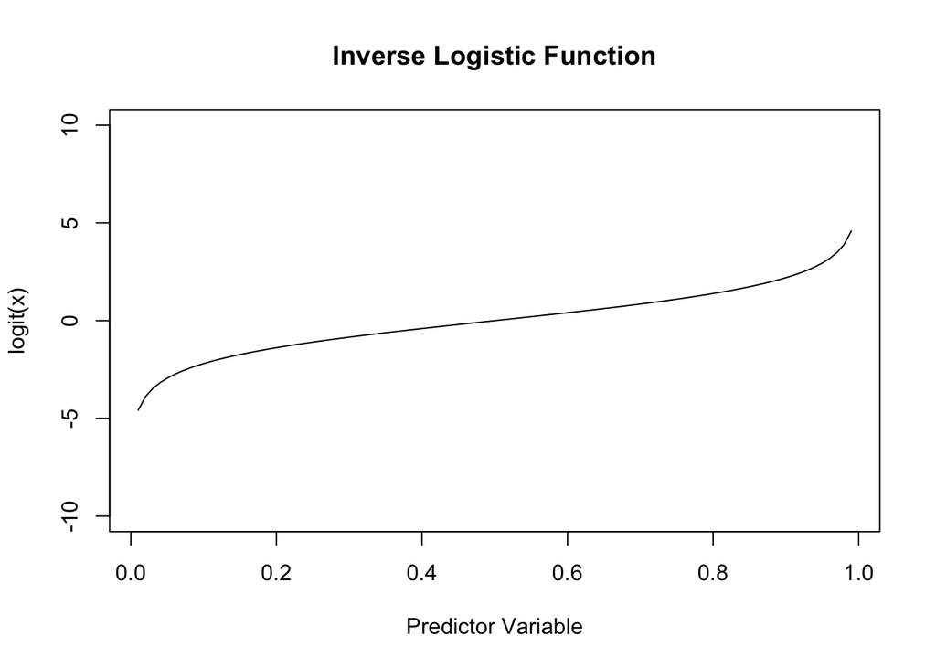

```r
#Plot inverse logistic function
plot(logit(x) ~ x, type="l", main="Inverse Logistic Function", xlab="Predictor Variable",ylab="logit(x)",ylim=c(-10,10))
```

# NYCFlights Model

Using the rectangular data that you created from the earlier assignment and following the example from the text and class, create a model for arr_delay >= 22 minutes. Describe/Explain each of the steps and show all work.

KNIT YOUR DOCUMENT AS *HTML* AND SUBMIT IT AND THE `Rmd` file to your repository.

```r
#Step 1: Load packages and data
library(readr)
library(dplyr)
library(caret)
#Read the following csv files from data folder from week 2 of class
airports <- read_csv("airports.csv")
flights <- read_csv("flights.csv")
planes <- read_csv("planes.csv")
weather <- read_csv("weather.csv")
#Combine datasets into one data table:
#Do a left join with flights and planes data sets and join by variable tailnum
combined <- left_join(flights, planes, by = "tailnum")
#Do another left join with the previous combined data set and airport by variable origin
combined <- left_join(combined, airports, c("origin" = "faa"))
#Repeat above set this time joining by destination, need to separate this because it has to be an OR join not AND
combined <- left_join(combined, airports, c("dest" = "faa"))
#Last left join, combine above with weather data set and join by origin AND date
combined <- left_join(combined, weather, by = c("origin" = "origin", "time_hour" = "time_hour"))
#There are 9,430 NA's out of 336,776 rows, delete the NAs
subsetcombined <- combined[!is.na(combined$arr_delay),]
#Keep only columns with numeric data
subsetcombined <- subset(subsetcombined, select = c(month.x, dep_time, dep_delay, arr_time, arr_delay, air_time, distance, hour.x, temp, dewp, humid, wind_dir, wind_speed, wind_gust, precip, pressure, visib))
#Create a new column called "delay22min" with two categories: flights with an arrival delay >= 22 min and flights with arrival delay < 22 min
subsetcombined$delay22min <- ifelse(subsetcombined$arr_delay >= 22, "delay >= 22 min", "delay < 22min")
subsetcombined$delay22min <- as.factor(subsetcombined$delay22min)

# setting seed to reproduce results of random sampling
set.seed(1000)
#row indices for training data
trainingRowIndex <- sample(1:nrow(subsetcombined), 0.7*nrow(subsetcombined))
#model training data
trainingData <- subsetcombined[trainingRowIndex, ]
#test data
testData <- subsetcombined[-trainingRowIndex, ]

#build the naive model
lmMod <- lm(arr_delay ~ dep_delay, data=trainingData)
summary(lmMod)
```

```
##
## Call:
## lm(formula = arr_delay ~ dep_delay, data = trainingData)
##
## Residuals:
##      Min       1Q   Median       3Q      Max
## -107.866  -11.014   -1.873    8.925  201.925
##
## Coefficients:
##               Estimate Std. Error t value Pr(>|t|)
## (Intercept) -5.8844592  0.0395268  -148.9   <2e-16 ***
## dep_delay    1.0202168  0.0009407  1084.5   <2e-16 ***
## ---
## Signif. codes:  0 '***' 0.001 '**' 0.01 '*' 0.05 '.' 0.1 ' ' 1
##
## Residual standard error: 18.05 on 229140 degrees of freedom
## Multiple R-squared:  0.8369, Adjusted R-squared:  0.8369
## F-statistic: 1.176e+06 on 1 and 229140 DF,  p-value: < 2.2e-16
```

```r
#Naive model provides an R-squared value of 0.8386

#build a better model
glmMod <- glm(formula = delay22min ~ dep_delay, family = binomial, data = trainingData)
summary(glmMod)
```

```
##
## Call:
## glm(formula = delay22min ~ dep_delay, family = binomial, data = trainingData)
##
## Deviance Residuals:
##     Min       1Q   Median       3Q      Max
## -3.3184  -0.3310  -0.2697  -0.2083   3.8422
##
## Coefficients:
##               Estimate Std. Error z value Pr(>|z|)
## (Intercept) -2.8770022  0.0106534  -270.1   <2e-16 ***
## dep_delay    0.1047372  0.0005164   202.8   <2e-16 ***
## ---
## Signif. codes:  0 '***' 0.001 '**' 0.01 '*' 0.05 '.' 0.1 ' ' 1
##
## (Dispersion parameter for binomial family taken to be 1)
##
##     Null deviance: 228823  on 229141  degrees of freedom
## Residual deviance: 102843  on 229140  degrees of freedom
## AIC: 102847
##
## Number of Fisher Scoring iterations: 7
```

```r
#predict arrival delay for naive model
arrdelayPredlm <- predict(lmMod, newdata=testData)

#predict arrival delay for better model
arrdelayPredglm <- predict(glmMod, newdata=testData)

#create a data frame comparing the observed values from the test data to the predicted values from the predicted values
modelvalueslm <- data.frame(obs = testData$arr_delay, pred=arrdelayPredlm)
modelvaluesglm <- data.frame(obs = testData$arr_delay, pred=arrdelayPredglm)

#show summary results for Root Mean Square Error and R-squared values
#Naive Model:
defaultSummary(modelvalueslm)
```

```
##      RMSE  Rsquared
## 17.967850  0.836693
```

```r
#Second Model:
defaultSummary(modelvaluesglm)
```

```
##      RMSE  Rsquared
## 41.508218  0.836693
```

# Question:

Is this a good model? Although the second model has the same R-squared value as the naive model (i.e., 0.837), the root mean squared error is more than twice as large as that of the naive, which means that the naive model is a better fit.

# PART B:

Your model should be good at explaining tardiness. Now, assume that your job is to predict arrival delays a month in advance. You can no longer use all the features in your model. Retrain your model using only features that will be *known* only a month in advance of the departure time. Show all steps as above.

```r
#Step 1: Create a second data frame for Part B and add a new column to separate flights with an arrival delay >= 22 min

#Combine datasets into one data table:
#Do a left join with flights and planes data sets and join by variable tailnum
combined2 <- left_join(flights, planes, by = "tailnum")
#Do another left join with the previous combined data set and airport by variable origin
combined2 <- left_join(combined2, airports, c("origin" = "faa"))
#Repeat above set this time joining by destination, need to separate this because it has to be an OR join not AND
combined2 <- left_join(combined2, airports, c("dest" = "faa"))
#There are 9,430 NA's out of 336,776 rows, delete the NAs
subsetcombined2 <- combined2[!is.na(combined2$arr_delay),]
#Keep only numeric variables that are known 1 month in advance of departure date
subsetcombined2 <- subset(subsetcombined2, select = c(month, sched_dep_time, sched_arr_time, carrier, distance, arr_delay))
#Create a new column called "delay22min" with two categories: flights with an arrival delay >= 22 min and flights with arrival delay < 22 min
subsetcombined2$delay22min <- ifelse(subsetcombined2$arr_delay >= 22, "delay >= 22 min", "delay < 22min")
subsetcombined2$delay22min <- as.factor(subsetcombined2$delay22min)

# setting seed to reproduce results of random sampling
set.seed(1000)
#row indices for training data
trainingRowIndex2 <- sample(1:nrow(subsetcombined2), 0.7*nrow(subsetcombined2))
#model training data
trainingData2 <- subsetcombined2[trainingRowIndex2, ]
#test data
testData2 <- subsetcombined2[-trainingRowIndex2, ]

#build the naive model
lmMod2 <- lm(arr_delay ~ ., data=trainingData2)
summary(lmMod2)
```

```
##
## Call:
## lm(formula = arr_delay ~ ., data = trainingData2)
##
## Residuals:
##     Min      1Q  Median      3Q     Max
##  -76.48  -13.76   -1.74   10.78 1204.21
##
## Coefficients:
##                             Estimate Std. Error t value Pr(>|t|)
## (Intercept)               -1.294e+01  3.734e-01 -34.644  < 2e-16 ***
## month                     -7.148e-02  1.846e-02  -3.872 0.000108 ***
## sched_dep_time             2.364e-03  2.220e-04  10.645  < 2e-16 ***
## sched_arr_time             4.265e-04  2.078e-04   2.052 0.040162 *
## carrierAA                 -4.334e-01  3.527e-01  -1.229 0.219083
## carrierAS                 -4.657e+00  1.383e+00  -3.367 0.000761 ***
## carrierB6                  3.138e+00  3.225e-01   9.730  < 2e-16 ***
## carrierDL                  1.426e+00  3.300e-01   4.322 1.55e-05 ***
## carrierEV                  4.160e+00  3.183e-01  13.068  < 2e-16 ***
## carrierF9                  9.733e+00  1.414e+00   6.882 5.90e-12 ***
## carrierFL                  8.439e+00  6.966e-01  12.114  < 2e-16 ***
## carrierHA                  5.862e+00  1.975e+00   2.968 0.003001 **
## carrierMQ                  3.043e+00  3.574e-01   8.516  < 2e-16 ***
## carrierOO                 -1.476e+00  7.319e+00  -0.202 0.840144
## carrierUA                  1.625e+00  3.317e-01   4.899 9.62e-07 ***
## carrierUS                  1.430e+00  3.772e-01   3.791 0.000150 ***
## carrierVX                  3.479e+00  6.132e-01   5.673 1.41e-08 ***
## carrierWN                  4.551e+00  4.327e-01  10.519  < 2e-16 ***
## carrierYV                  2.839e+00  1.567e+00   1.811 0.070070 .
## distance                  -1.830e-03  1.073e-04 -17.055  < 2e-16 ***
## delay22mindelay >= 22 min  8.128e+01  1.619e-01 502.148  < 2e-16 ***
## ---
## Signif. codes:  0 '***' 0.001 '**' 0.01 '*' 0.05 '.' 0.1 ' ' 1
##
## Residual standard error: 30.15 on 229121 degrees of freedom
## Multiple R-squared:  0.5451, Adjusted R-squared:  0.5451
## F-statistic: 1.373e+04 on 20 and 229121 DF,  p-value: < 2.2e-16
```

```r
#Naive model provides an R-squared value of 0.8386

#build a better model
glmMod2 <- glm(formula = delay22min ~ ., family = binomial, data = trainingData2)
summary(glmMod2)
```

```
##
## Call:
## glm(formula = delay22min ~ ., family = binomial, data = trainingData2)
##
## Deviance Residuals:
##        Min          1Q      Median          3Q         Max
## -7.792e-04  -2.000e-08  -2.000e-08  -2.000e-08   9.128e-04
##
## Coefficients:
##                  Estimate Std. Error z value Pr(>|z|)
## (Intercept)    -6.581e+02  1.098e+03  -0.599    0.549
## month           9.785e-03  7.144e+00   0.001    0.999
## sched_dep_time  9.155e-05  8.776e-02   0.001    0.999
## sched_arr_time -5.487e-05  8.132e-02  -0.001    0.999
## carrierAA       2.909e-01  1.532e+02   0.002    0.998
## carrierAS      -3.193e-01  6.917e+02   0.000    1.000
## carrierB6       9.679e-02  1.370e+02   0.001    0.999
## carrierDL       2.547e-01  1.421e+02   0.002    0.999
## carrierEV       1.339e-01  1.358e+02   0.001    0.999
## carrierF9       3.512e-01  3.904e+02   0.001    0.999
## carrierFL       5.877e-02  2.243e+02   0.000    1.000
## carrierHA       2.415e+01  2.718e+04   0.001    0.999
## carrierMQ       1.042e-01  1.477e+02   0.001    0.999
## carrierOO       4.505e+02  9.358e+04   0.005    0.996
## carrierUA       4.517e-02  1.424e+02   0.000    1.000
## carrierUS       1.409e-01  1.604e+02   0.001    0.999
## carrierVX       2.385e-01  2.624e+02   0.001    0.999
## carrierWN       1.195e-02  1.809e+02   0.000    1.000
## carrierYV       4.086e-01  5.875e+02   0.001    0.999
## distance       -4.652e-05  4.405e-02  -0.001    0.999
## arr_delay       3.060e+01  5.054e+01   0.605    0.545
##
## (Dispersion parameter for binomial family taken to be 1)
##
##     Null deviance: 2.2882e+05  on 229141  degrees of freedom
## Residual deviance: 1.1528e-03  on 229121  degrees of freedom
## AIC: 42.001
##
## Number of Fisher Scoring iterations: 25
```

```r
#predict arrival delay for naive model
arrdelayPredlm2 <- predict(lmMod2, newdata=testData2)

#predict arrival delay for better model
arrdelayPredglm2 <- predict(glmMod2, newdata=testData2)

#create a data frame comparing the observed values from the test data to the predicted values from the predicted values
modelvalueslm2 <- data.frame(obs = testData2$arr_delay, pred=arrdelayPredlm2)
modelvaluesglm2 <- data.frame(obs = testData2$arr_delay, pred=arrdelayPredglm2)

#show summary results for Root Mean Square Error and R-squared values
#Naive Model:
defaultSummary(modelvalueslm2)
```

```
##       RMSE   Rsquared
## 29.8560039  0.5490656
```

```r
#Second Model:
defaultSummary(modelvaluesglm2)
```

```
##         RMSE     Rsquared
## 1393.2626487    0.9999863
```

# Part B Results:

For this part, the variables month, sched_dep_time, sched_arr_time, carrier, distance were used. While running the naive and second model, all predictor variables were used (unlike in Part A, where it was just the departure delay). Interestingly, the naive model has a lower R-squared value of 0.55 compared to the second model of 0.9999. However the root mean square error for the second model is much greater than that of the naive model, so the naive model appears to have a better absolute measure of fit and a poorer relative measure of fit.